# Séries de tempo, ciclo, sazonalidade e tendência

Importando libraries:

`r`r install.packages()

`r`r install.packages()

`r`r install.packages()

[output not shown]

`r`r install.packages()

```
  There is a binary version available but the source version is later:
```

|  | binary | source | needs_compilation |
| --- | --- | --- | --- |
| janitor | 1.2.1 | 2.0.0 | FALSE |

[output not shown]

`r`r install.packages()

`r`r install.packages()

`r`r library(tidyverse)

`r`r library(corrplot)

`r`r library(janitor)

`r`r library(lubridate)

`r`r library(gapminder) library(fpp2)

`r`r library(seasonal)

[output not shown]

Setando o diretório corrente:

`r`r setwd(dirname(rstudioapi::getActiveDocumentContext()$path)) getwd()

```
[1] \/Users/adrianosastre/Dropbox/Data Science/Exercícios/datascience-exercises-april-13-2020/R/2\
```

O arquivo “retail.xlsx” contém informações sobre vendas mensais de varejo para diversos estados da Austrália.

1. Leia os dados contidos no arquivo “retail.xlsx”.

`r`r retail_data = readxl::read_excel(./retail.xlsx, skip = 1) retail_data = janitor::clean_names(retail_data)

View(retail_data)

Qual cuidado adicional você precisou ter ao realizar essa importação?

RESPOSTA = - Tive que utilizar a função readxl::read_excel passando o parâmetro skip = 1 para não importar a primeira linha da planilha.

2. Selecione uma das variáveis e as converta para o formato “time series”.

`r`r retail_data$series_id = lubridate::ymd(retail_data$series_id) class(retail_data$series_id)

```
[1] \Date\
```

`r`r # a3349396w = Turnover ; Total (State) ; Total (Industry) ; # first date = 1982-04-01

retail_data_total_ts <- ts(retail_data$a3349396w, start = c(1982, 1), frequency = 12) class(retail_data_total_ts)

```
[1] \ts\
```

RESPOSTA = series_id convertido para date, criado variável retail_data_total_ts como time-series do total de turnover, desde 1982.

3. Explore a série escolhida por meio da construção de gráficos. Em particular, se estiver utilizando o R, teste as funções ggseasonplot e ggmonthplot.

`r`r # a3349396w = Turnover ; Total (State) ; Total (Industry) ;

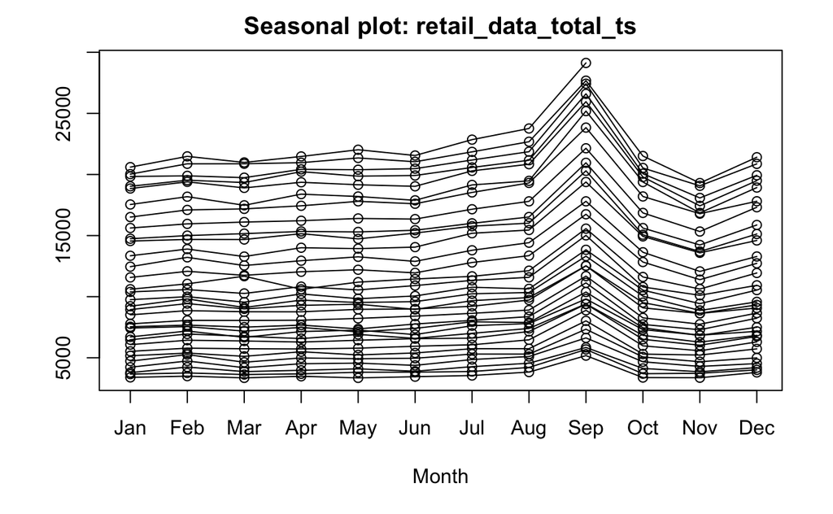

`r`r

ggseasonplot( x = retail_data_total_ts, season.labels = NULL, year.labels = FALSE, year.labels.left = FALSE, type = NULL, col = NULL, continuous = TRUE, polar = FALSE, labelgap = 0.04 )

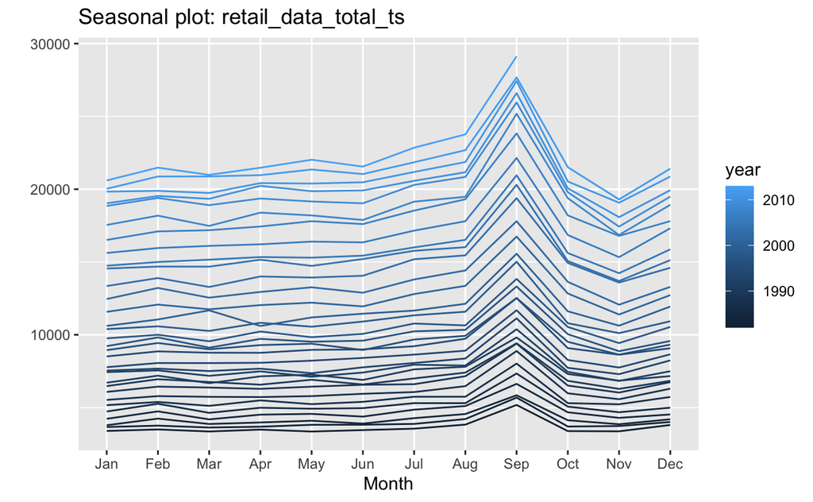

`r`r

ggseasonplot( x = retail_data_total_ts, season.labels = NULL, year.labels = FALSE, year.labels.left = FALSE, type = NULL, col = NULL, continuous = TRUE, polar = TRUE, )

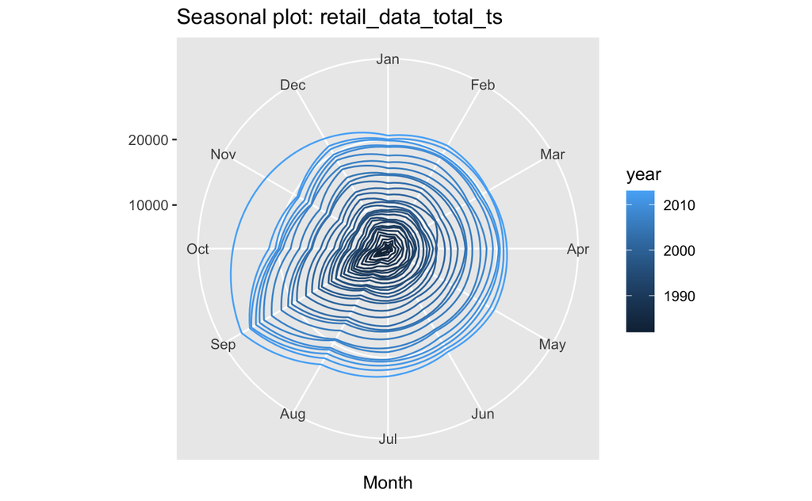

`r`r

ggmonthplot( x = retail_data_total_ts )

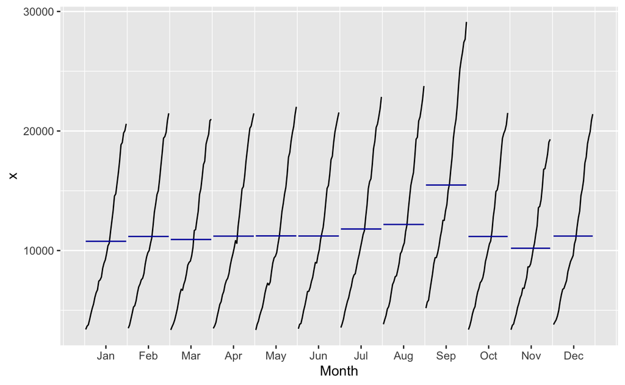

4. Decomponha a série utilizando o método X11.

autoplot(fit_x11) + ggtitle(Turnover)

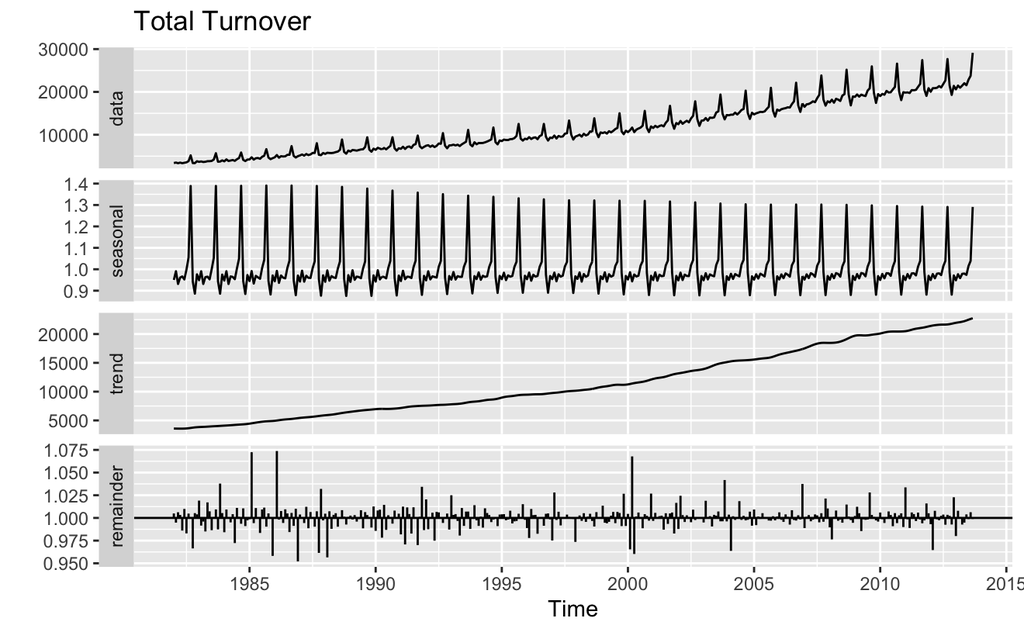

`r`r

[figure not shown]

Ele revela algum outlier ou padrões anômalos não identificados anteriormente?